# Coursera Practical Machine Learning Final Project

Kevin Huang

November 16, 2017

# Background

Using devices such as Jawbone Up, Nike FuelBand, and Fitbit it is now possible to collect a large amount of data about personal activity relatively inexpensively. These type of devices are part of the quantified self movement - a group of enthusiasts who take measurements about themselves regularly to improve their health, to find patterns in their behavior, or because they are tech geeks. One thing that people regularly do is quantify how much of a particular activity they do, but they rarely quantify how well they do it. In this project, your goal will be to use data from accelerometers on the belt, forearm, arm, and dumbell of 6 participants. They were asked to perform barbell lifts correctly and incorrectly in 5 different ways. More information is available from the website here: http://web.archive.org/web/20161224072740/http:/groupware.les.inf.puc-rio.br/har (see the section on the Weight Lifting Exercise Dataset).

# Data

The training data for this project are available here:

https://d396qusza40orc.cloudfront.net/predmachlearn/pml-training.csv

The test data are available here:

https://d396qusza40orc.cloudfront.net/predmachlearn/pml-testing.csv

The data for this project come from this source: http://web.archive.org/web/20161224072740/http:/groupware.les.inf.puc-rio.br/har. If you use the document you create for this class for any purpose please cite them as they have been very generous in allowing their data to be used for this kind of assignment.

# Data Processing

We are going to spilt the training data into a training set *df.train* and a testing set *df.test* by 6:4 ratio. The original test set will only be using for generating the quiz result.

### Download the data from the provided URL, and load it into R

```r
library(caret)
library(randomForest)
library(rpart)
library(rattle)

trainUrl <- "https://d396qusza40orc.cloudfront.net/predmachlearn/pml-training.csv"
testUrl <- "https://d396qusza40orc.cloudfront.net/predmachlearn/pml-testing.csv"
trainFile <- "pml-trainging.csv"
testFile <- "pml-testing.csv"
if (!file.exists(trainFile)){download.file(trainUrl, trainFile, method = "curl")}
if (!file.exists(testFile)){download.file(testUrl, testFile, method = "curl")}

training <- read.csv(trainFile)
testing <- read.csv(testFile)
dim(training)
```

```
## [1] 19622   160
```

### Data Partition

```r
inTrain <- createDataPartition(training$classe, p = .6, list = FALSE)
df.train <- training[inTrain,]
df.test <- training[-inTrain,]

dim(df.train)
```

```
## [1] 11776   160
```

```r
dim(df.test)
```

```
## [1] 7846  160
```

We total have 160 variables. However, not all variables are relevent in the prediction. Therefore, we will have to perform data cleaning.

### Data Cleaning

We are going to remove the NA’s, the Near Zero Variance(NZR), and the ID variables.

```r
# remove columns only contain NA's
df.train <- df.train[, colSums(is.na(df.train)) == 0]
df.test <- df.test[, colSums(is.na(df.test)) == 0]
# remove the Near Zero Variance columns
NZV <- nearZeroVar(df.train)
df.train <- df.train[,-NZV]
df.test <- df.test[,-NZV]
# remove ID variables
df.train <- df.train[,-(1:5)]
df.test <- df.test[,-(1:5)]
# check dimention
dim(df.train)
```

```
## [1] 11776    54
```

```r
dim(df.test)
```

```
## [1] 7846   54
```

After data cleaning, we will have 54 variables for the analysis.

# Model Building

We will build 3 models using Random Forest, Generalized Boosted Model, and Decision Tree. The model with the highest accuracy rate will be used to answer the quiz questions.

For Cross Validation, we will be using 7-folds Cross Validation.

### Random Forest

First of all, we will build a Random Forest model and perform a prediction

```r
mod.rf <- randomForest(classe ~., data = df.train, trControl = trainControl("cv", number = 7))
mod.rf
```

```
##
## Call:
##  randomForest(formula = classe ~ ., data = df.train, trControl = trainControl("cv",      number = 7))
##                Type of random forest: classification
##                      Number of trees: 500
## No. of variables tried at each split: 7
##
##         OOB estimate of  error rate: 0.35%
## Confusion matrix:
##      A    B    C    D    E  class.error
## A 3347    0    0    0    1 0.0002986858
## B    7 2269    3    0    0 0.0043878894
## C    0    9 2043    2    0 0.0053554041
## D    0    0   12 1918    0 0.0062176166
## E    0    0    0    7 2158 0.0032332564
```

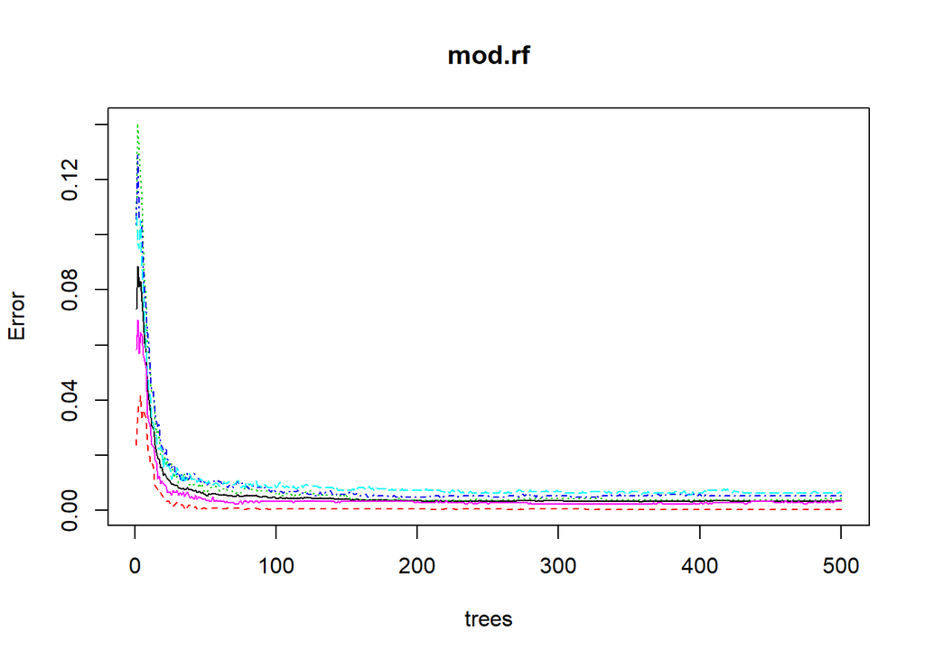

```r
plot(mod.rf)
```

#### Prediction with Random Forest model

```r
pred.rf <- predict(mod.rf, df.test)
result.rf <- confusionMatrix(pred.rf, df.test$classe)
result.rf$overall[1]
```

```
##  Accuracy
## 0.9960489
```

### Generalized Boosted Model (GBM)

```r
mod.gbm <- train(classe ~., data = df.train, method = "gbm", verbose = FALSE,
                 trControl = trainControl(method = "cv", number = 7))
mod.gbm
```

```
## Stochastic Gradient Boosting
##
## 11776 samples
##    53 predictor
##     5 classes: 'A', 'B', 'C', 'D', 'E'
##
## No pre-processing
## Resampling: Cross-Validated (7 fold)
## Summary of sample sizes: 10094, 10094, 10094, 10092, 10094, 10094, ...
## Resampling results across tuning parameters:
##
##   interaction.depth  n.trees  Accuracy   Kappa
##   1                   50      0.7575582  0.6923738
##   1                  100      0.8316053  0.7868796
##   1                  150      0.8701599  0.8357341
##   2                   50      0.8811154  0.8495345
##   2                  100      0.9402193  0.9243452
##   2                  150      0.9643360  0.9548677
##   3                   50      0.9353787  0.9182165
##   3                  100      0.9708745  0.9631471
##   3                  150      0.9843764  0.9802368
##
## Tuning parameter 'shrinkage' was held constant at a value of 0.1
##
## Tuning parameter 'n.minobsinnode' was held constant at a value of 10
## Accuracy was used to select the optimal model using  the largest value.
## The final values used for the model were n.trees = 150,
##  interaction.depth = 3, shrinkage = 0.1 and n.minobsinnode = 10.
```

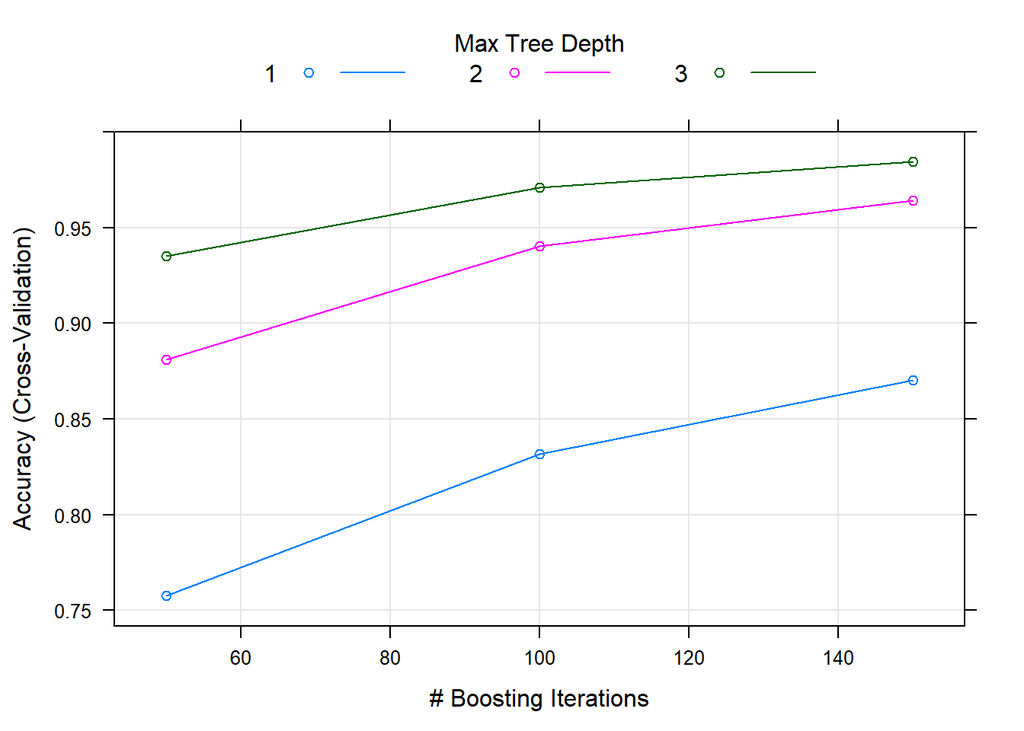

```r
plot(mod.gbm)
```

#### Prediction with Generalized Boosted Model

```r
pred.gbm <- predict(mod.gbm, df.test)
result.gbm <- confusionMatrix(pred.gbm, df.test$classe)
result.gbm$overall[1]
```

```
##  Accuracy
## 0.9849605
```

### Decision Tree

```r
mod.rpart <- rpart(classe ~., data = df.train, method = "class",
                   control = rpart.control(method = "cv", number = 7))
mod.rpart
```

```
## n= 11776
##
## node), split, n, loss, yval, (yprob)
##       * denotes terminal node
##
##    1) root 11776 8428 A (0.28 0.19 0.17 0.16 0.18)
##      2) roll_belt< 130.5 10782 7446 A (0.31 0.21 0.19 0.18 0.11)
##        4) pitch_forearm< -33.15 956   13 A (0.99 0.014 0 0 0) *
##        5) pitch_forearm>=-33.15 9826 7433 A (0.24 0.23 0.21 0.2 0.12)
##         10) magnet_dumbbell_y< 438.5 8325 5975 A (0.28 0.18 0.24 0.19 0.11)
##           20) roll_forearm< 124.5 5218 3096 A (0.41 0.18 0.18 0.17 0.062)
##             40) magnet_dumbbell_z< -27.5 1753  586 A (0.67 0.2 0.015 0.083 0.034) *
##             41) magnet_dumbbell_z>=-27.5 3465 2510 A (0.28 0.17 0.27 0.22 0.076)
##               82) num_window< 241.5 820  129 A (0.84 0.0012 0 0.059 0.098) *
##               83) num_window>=241.5 2645 1721 C (0.1 0.22 0.35 0.27 0.07)
##                166) accel_dumbbell_y< -40.5 378   28 C (0 0.048 0.93 0.026 0) *
##                167) accel_dumbbell_y>=-40.5 2267 1576 D (0.12 0.24 0.25 0.3 0.081)
##                  334) roll_belt>=125.5 528  207 C (0 0.35 0.61 0.038 0.0038)
##                    668) pitch_belt< -42.75 196   17 B (0 0.91 0 0.077 0.01) *
##                    669) pitch_belt>=-42.75 332   11 C (0 0.018 0.97 0.015 0) *
##                  335) roll_belt< 125.5 1739 1068 D (0.15 0.21 0.15 0.39 0.1)
##                    670) num_window< 260 101    0 B (0 1 0 0 0) *
##                    671) num_window>=260 1638  967 D (0.16 0.16 0.15 0.41 0.11)
##                     1342) num_window< 278.5 98    0 C (0 0 1 0 0) *
##                     1343) num_window>=278.5 1540  869 D (0.17 0.17 0.1 0.44 0.12)
##                       2686) pitch_belt< -42.45 321  198 A (0.38 0.34 0.19 0.081 0.0093) *
##                       2687) pitch_belt>=-42.45 1219  574 D (0.12 0.13 0.078 0.53 0.15) *
##           21) roll_forearm>=124.5 3107 2073 C (0.073 0.18 0.33 0.23 0.19)
##             42) magnet_dumbbell_y< 291.5 1817  926 C (0.091 0.13 0.49 0.14 0.14)
##               84) magnet_forearm_z< -245.5 142   25 A (0.82 0.049 0 0.042 0.085) *
##               85) magnet_forearm_z>=-245.5 1675  784 C (0.029 0.14 0.53 0.15 0.15)
##                170) num_window< 88.5 197   86 B (0.091 0.56 0 0 0.35) *
##                171) num_window>=88.5 1478  587 C (0.021 0.083 0.6 0.17 0.12) *
##             43) magnet_dumbbell_y>=291.5 1290  842 D (0.048 0.25 0.11 0.35 0.25)
##               86) accel_forearm_x>=-101.5 810  523 E (0.033 0.31 0.15 0.15 0.35)
##                172) roll_dumbbell< 40.44125 166   32 B (0.042 0.81 0.012 0.036 0.1) *
##                173) roll_dumbbell>=40.44125 644  374 E (0.031 0.18 0.19 0.18 0.42) *
##               87) accel_forearm_x< -101.5 480  153 D (0.073 0.14 0.04 0.68 0.067) *
##         11) magnet_dumbbell_y>=438.5 1501  720 B (0.029 0.52 0.046 0.22 0.19)
##           22) total_accel_dumbbell>=5.5 1088  371 B (0.04 0.66 0.062 0.019 0.22)
##             44) roll_belt>=-0.575 914  197 B (0.047 0.78 0.073 0.023 0.072) *
##             45) roll_belt< -0.575 174    0 E (0 0 0 0 1) *
##           23) total_accel_dumbbell< 5.5 413  107 D (0 0.15 0.0048 0.74 0.099) *
##      3) roll_belt>=130.5 994   12 E (0.012 0 0 0 0.99) *
```

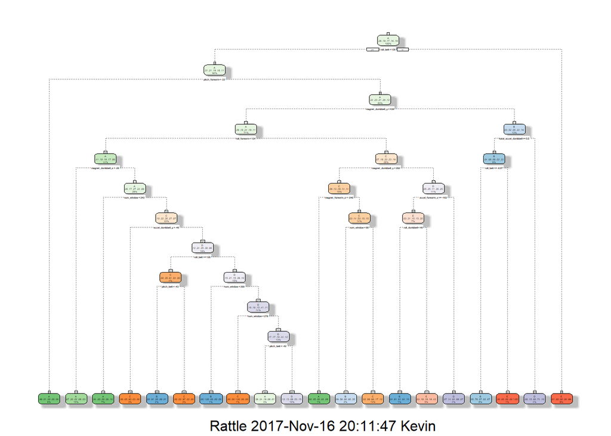

```r
fancyRpartPlot(mod.rpart)
```

#### Prediction with Decision Tree model

```r
pred.rpart <- predict(mod.rpart, df.test, type = "class")
result.rpart <- confusionMatrix(pred.rpart, df.test$classe)
result.rpart$overall[1]
```

```
## Accuracy
## 0.723171
```

# Selected Model Apply to the Quiz

From the above result we can see that the Random Forest Model has the highest accuracy rate (0.996), so we will use this model to answer the quiz questions. The result is shown below.

```r
pred.quiz <- predict(mod.rf, testing)
pred.quiz
```

```
##  1  2  3  4  5  6  7  8  9 10 11 12 13 14 15 16 17 18 19 20
##  B  A  B  A  A  E  D  B  A  A  B  C  B  A  E  E  A  B  B  B
## Levels: A B C D E
```